# Practical Machine Learning: Assignment

ND

18/11/2014

# Executive Summary

# Introduction

The analysis described here was carried out using R (R Core Team 2014). Tables were formatted using xtable (Dahl 2014) and the plots were created with ggplot2 (Wickham 2009). Much of the underlying code in the R Markdown source has been hidden to aid readability. The full source can be found in my [github repository](https://github.com/ndoylend/Coursera_PredMachLearn).

# Data Processing

The first step in the analysis is to load the training data from the .csv file provided. The raw data contains 160 variables, however not all of them are useful features for model training. Since the model is intended to predict mistake class on the basis of data from the wearable inertial measurement units, unnecessary variables such as ID and timestamps have been removed. The raw data also contains summary statistics of the measurements calculated at sliding time windows. These data were used in the prediction algorithm described in the original paper but do not appear in the test data provided for this exercise and are therefore not used in this analysis.

The following features were used in this analysis:

```
##  [1] "roll_belt"            "pitch_belt"           "yaw_belt"
##  [4] "total_accel_belt"     "gyros_belt_x"         "gyros_belt_y"
##  [7] "gyros_belt_z"         "accel_belt_x"         "accel_belt_y"
## [10] "accel_belt_z"         "magnet_belt_x"        "magnet_belt_y"
## [13] "magnet_belt_z"        "roll_arm"             "pitch_arm"
## [16] "yaw_arm"              "total_accel_arm"      "gyros_arm_x"
## [19] "gyros_arm_y"          "gyros_arm_z"          "accel_arm_x"
## [22] "accel_arm_y"          "accel_arm_z"          "magnet_arm_x"
## [25] "magnet_arm_y"         "magnet_arm_z"         "roll_dumbbell"
## [28] "pitch_dumbbell"       "yaw_dumbbell"         "total_accel_dumbbell"
## [31] "gyros_dumbbell_x"     "gyros_dumbbell_y"     "gyros_dumbbell_z"
## [34] "accel_dumbbell_x"     "accel_dumbbell_y"     "accel_dumbbell_z"
## [37] "magnet_dumbbell_x"    "magnet_dumbbell_y"    "magnet_dumbbell_z"
## [40] "roll_forearm"         "pitch_forearm"        "yaw_forearm"
## [43] "total_accel_forearm"  "gyros_forearm_x"      "gyros_forearm_y"
## [46] "gyros_forearm_z"      "accel_forearm_x"      "accel_forearm_y"
## [49] "accel_forearm_z"      "magnet_forearm_x"     "magnet_forearm_y"
## [52] "magnet_forearm_z"
```

# Data Partitioning

The tidied data was divided 70/30 into a training set and a testing set. The training set is used to create the models while the testing set is reserved for evaluation the models’ out-of-sample prediction accuracy.

The training set contains 13737 rows with the following breakdown of mistake class:

```
##    A    B    C    D    E
## 3906 2658 2396 2252 2525
```

# Model Creation

## Modelling with rpart

My first attempt at model creation was using the rpart package (Therneau, Atkinson, and Ripley 2014):

```r
modName <- "modFit.rpart1"
filename <- paste0(modName,".RData")

if (file.exists(filename)) {
  load(file = filename)
} else {
  time <- system.time(modFit <- rpart(classe ~ ., data = training))
  save(modFit, time, file = filename, compress=TRUE)
}

predicted <- predict(modFit, newdata = testing)
predicted <- as.factor(apply(predicted, 1, which.max))
levels(predicted) <- c("A","B","C","D","E")
results <- confusionMatrix(data = predicted, reference = testing$classe)

summary.rpart1 <- data.frame(model ="rpart",
                       accuracy = results$overall[["Accuracy"]],
                       time = time[["elapsed"]],
                       size = format(object.size(modFit), units = "Mb"))
```

The model was quick to generate and resulted an an overall out-of-sample accuracy of 75.2%. Not bad for a first attempt, but hopefully better accuracy can be achieved with more sophisticated methods. Table 1 shows the confusion matrix (reference class by column and predicted class by row).

*Table 1: Confusion matrix: rpart*

|  | A | B | C | D | E |
| --- | --- | --- | --- | --- | --- |
| A | 1473 | 164 | 11 | 46 | 19 |
| B | 53 | 715 | 51 | 71 | 100 |
| C | 54 | 117 | 839 | 154 | 137 |
| D | 59 | 76 | 64 | 620 | 49 |
| E | 35 | 67 | 61 | 73 | 777 |

Table 2 shows the top 5 most important variables in the rpart model.

*Table 2: Top 5 variable importance: rpart*

|  | Overall |
| --- | --- |
| roll_belt | 2012.78 |
| pitch_forearm | 1676.25 |
| roll_forearm | 1535.90 |
| magnet_dumbbell_z | 1510.68 |
| yaw_belt | 1481.10 |

## Modelling with caret

Subsequent models were created using the caret package (Kuhn et al. 2014). The `trainControl` function was used to configure a 5-fold cross validation and the `train` function was then used to train the actual models.

```r
modControl <- trainControl(method = "cv", number = 5, repeats = 1)
```

### Recursive Partitioning and Regression Trees (caret/rpart)

My first attempt with caret used `method = "rpart"`:

```r
modName <- "modFit.rpart2"

filename <- paste0(modName,".RData")
if (file.exists(filename)) {
  load(file = filename)
} else {
  time <- system.time(modFit <- train(classe ~ ., method = "rpart",
                                          trControl = modControl, data = training))
  save(modFit, time, file = filename, compress=TRUE)
}

predicted <- predict(modFit, newdata = testing)
results <- confusionMatrix(data = predicted, reference = testing$classe)

summary.rpart2 <- data.frame(model ="caret/rpart",
                       accuracy = results$overall[["Accuracy"]],
                       time = time[["elapsed"]],
                       size = format(object.size(modFit), units = "Mb"))
```

The results from using `method = "rpart"` within caret did not result in a usable model; the model accuracy was 49.4%, which is worse than using `rpart` on its own. Presumably this is a result of incorrect settings with caret and could be improved given a deeper understanding of caret’s configuration options.

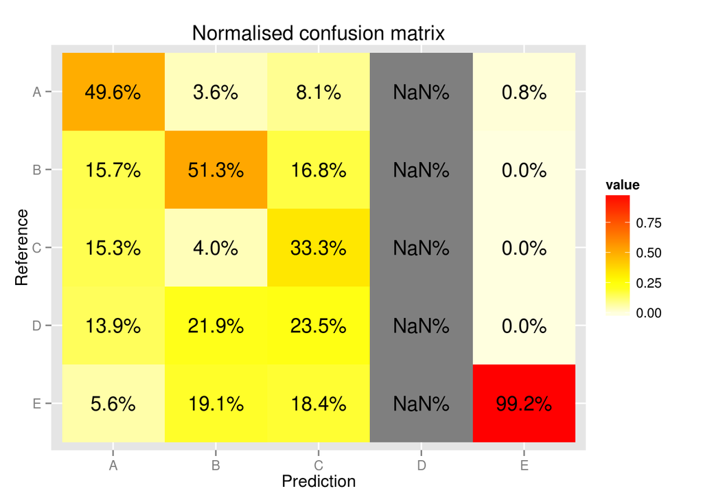

*Figure 1: Confusion matrix: caret/rpart*

NB The column of NaN% values occurs because prediction column for class D is completely empty.

### Linear Discriminant Algorithm (caret/lda)

The next attempt used `method = "lda"`. The results were an improvement, but an accuracy of 70.6% is still less than that achieved with `rpart`.

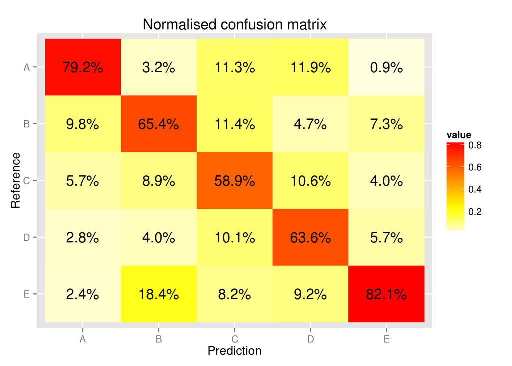

*Figure 2: Confusion matrix: caret/lda*

### Stochastic Gradient Boosting (caret/gbm)

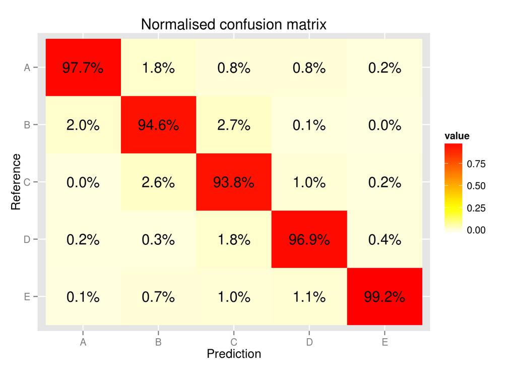

*Figure 3: Confusion matrix: caret/gbm*

### Random Forest (caret/rf)

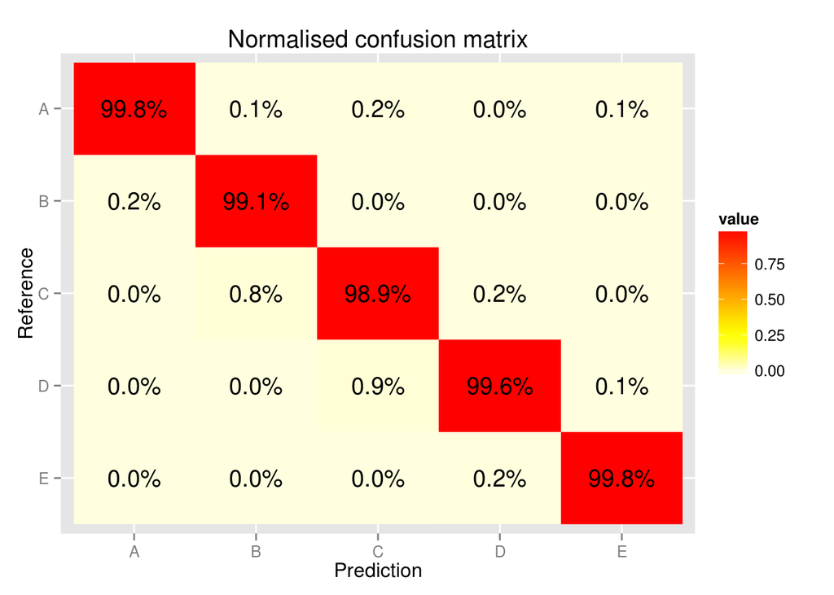

*Figure 4: Confusion matrix: caret/rf*

# Results

The results of the five models tested are shown in the table below, which lists out-of-sample accuracy, model training time (in seconds) and model object size.

*Table 3: Model comparison*

[output not shown]

# Conclusion

Of the models tested, the Random Forest method achieved the highest accuracy and correctly predicted all twenty test cases used in the final evaluation of the model. Subsequent testing showed that the Stochastic Gradient Boosting method correctly predicted all but one of the test cases. Random Forest is therefore the preferred method for accurate modelling, provided sufficient computing power is available. While slightly less accurate in this instance, Stochastic Gradient Boosting appears to provide a reasonable compromise between computational cost and accuracy. The caret models used a 5-fold cross validation but otherwise all models were used with their default settings; these could no doubt be tweaked to improve performance.

References

Dahl, David B. 2014. *xtable: Export Tables to LaTeX or HTML*. http://CRAN.R-project.org/package=xtable.

Kuhn, Max, Jed Wing, Steve Weston, Andre Williams, Chris Keefer, Allan Engelhardt, and others. 2014. *caret: Classification and Regression Training*. http://CRAN.R-project.org/package=caret.

R Core Team. 2014. *R: A Language and Environment for Statistical Computing*. Vienna, Austria: R Foundation for Statistical Computing. http://www.R-project.org/.

Therneau, Terry, Beth Atkinson, and Brian Ripley. 2014. *rpart: Recursive Partitioning and Regression Trees*. http://CRAN.R-project.org/package=rpart.

Velloso, Eduardo, Andreas Bulling, Hans Gellersen, Wallace Ugulino, and Hugo Fuks. 2013. “Qualitative Activity Recognition of Weight Lifting Exercises.” In *Proceedings of 4th International Conference in Cooperation with SIGCHI (Augmented Human ’13)*. Stuttgart, Germany. http://groupware.les.inf.puc-rio.br/work.jsf?p1=11201.

Wickham, Hadley. 2009. *ggplot2: elegant Graphics for Data Analysis*. Springer New York. http://had.co.nz/ggplot2/book.